# Exercise 6.4

Lucia Camenisch

16 novembre 2022

First of all, we upload the necessary packages.

```r
library(data.table)   # data table, fread()
library(ggplot2)      # plotting
library(dplyr)        # %>% function
library(tidyr)        # gather()
library(caret)        # preProcess() for scaling data
library(forecast)     # accuracy()


options(scipen = 999) # disable scientific notation
```

Then, we load our data and keep only the relevant variables for this exercise.

```r
ToyotaCorolla <- fread("ToyotaCorolla.csv") # importing data
# selecting columns cited in exercise
ToyotaCorolla <- ToyotaCorolla[, list(Price, Age_08_04, KM, Fuel_Type, HP, Automatic,
                                      Doors, Quarterly_Tax, Mfr_Guarantee,
                                      Guarantee_Period, Airco, Automatic_airco,
                                      CD_Player, Powered_Windows, Sport_Model, Tow_Bar)]
```

We examine its structure using `str`, get a first idea of the variables distributions using `summary` and print a table of the number of unique values each variable takes.

```r
str(ToyotaCorolla)                                          # data structure
```

```
## Classes 'data.table' and 'data.frame':   1436 obs. of  16 variables:
##  $ Price           : int  13500 13750 13950 14950 13750 12950 16900 18600 21500 12950 ...
##  $ Age_08_04       : int  23 23 24 26 30 32 27 30 27 23 ...
##  $ KM              : int  46986 72937 41711 48000 38500 61000 94612 75889 19700 71138 ...
##  $ Fuel_Type       : chr  "Diesel" "Diesel" "Diesel" "Diesel" ...
##  $ HP              : int  90 90 90 90 90 90 90 90 192 69 ...
##  $ Automatic       : int  0 0 0 0 0 0 0 0 0 0 ...
##  $ Doors           : int  3 3 3 3 3 3 3 3 3 3 ...
##  $ Quarterly_Tax   : int  210 210 210 210 210 210 210 210 100 185 ...
##  $ Mfr_Guarantee   : int  0 0 1 1 1 0 0 1 0 0 ...
##  $ Guarantee_Period: int  3 3 3 3 3 3 3 3 3 3 ...
##  $ Airco           : int  0 1 0 0 1 1 1 1 1 1 ...
##  $ Automatic_airco : int  0 0 0 0 0 0 0 0 0 0 ...
##  $ CD_Player       : int  0 1 0 0 0 0 0 1 0 0 ...
##  $ Powered_Windows : int  1 0 0 0 1 1 1 1 1 0 ...
##  $ Sport_Model     : int  0 0 0 0 0 0 1 0 0 0 ...
##  $ Tow_Bar         : int  0 0 0 0 0 0 0 0 0 0 ...
##  - attr(*, ".internal.selfref")=<externalptr>
```

```r
summary(ToyotaCorolla)                                      # data summary
```

```
##      Price         Age_08_04           KM          Fuel_Type
##  Min.   : 4350   Min.   : 1.00   Min.   :     1   Length:1436
##  1st Qu.: 8450   1st Qu.:44.00   1st Qu.: 43000   Class :character
##  Median : 9900   Median :61.00   Median : 63390   Mode  :character
##  Mean   :10731   Mean   :55.95   Mean   : 68533
##  3rd Qu.:11950   3rd Qu.:70.00   3rd Qu.: 87021
##  Max.   :32500   Max.   :80.00   Max.   :243000
##        HP          Automatic           Doors       Quarterly_Tax
##  Min.   : 69.0   Min.   :0.00000   Min.   :2.000   Min.   : 19.00
##  1st Qu.: 90.0   1st Qu.:0.00000   1st Qu.:3.000   1st Qu.: 69.00
##  Median :110.0   Median :0.00000   Median :4.000   Median : 85.00
##  Mean   :101.5   Mean   :0.05571   Mean   :4.033   Mean   : 87.12
##  3rd Qu.:110.0   3rd Qu.:0.00000   3rd Qu.:5.000   3rd Qu.: 85.00
##  Max.   :192.0   Max.   :1.00000   Max.   :5.000   Max.   :283.00
##  Mfr_Guarantee    Guarantee_Period     Airco        Automatic_airco
##  Min.   :0.0000   Min.   : 3.000   Min.   :0.0000   Min.   :0.00000
##  1st Qu.:0.0000   1st Qu.: 3.000   1st Qu.:0.0000   1st Qu.:0.00000
##  Median :0.0000   Median : 3.000   Median :1.0000   Median :0.00000
##  Mean   :0.4095   Mean   : 3.815   Mean   :0.5084   Mean   :0.05641
##  3rd Qu.:1.0000   3rd Qu.: 3.000   3rd Qu.:1.0000   3rd Qu.:0.00000
##  Max.   :1.0000   Max.   :36.000   Max.   :1.0000   Max.   :1.00000
##    CD_Player      Powered_Windows  Sport_Model        Tow_Bar
##  Min.   :0.0000   Min.   :0.000   Min.   :0.0000   Min.   :0.0000
##  1st Qu.:0.0000   1st Qu.:0.000   1st Qu.:0.0000   1st Qu.:0.0000
##  Median :0.0000   Median :1.000   Median :0.0000   Median :0.0000
##  Mean   :0.2187   Mean   :0.562   Mean   :0.3001   Mean   :0.2779
##  3rd Qu.:0.0000   3rd Qu.:1.000   3rd Qu.:1.0000   3rd Qu.:1.0000
##  Max.   :1.0000   Max.   :1.000   Max.   :1.0000   Max.   :1.0000
```

```r
t(t(sapply(ToyotaCorolla, function(x) length(unique(x)))))  # number of unique values
```

```
##                  [,1]
## Price             236
## Age_08_04          77
## KM               1263
## Fuel_Type           3
## HP                 12
## Automatic           2
## Doors               4
## Quarterly_Tax      13
## Mfr_Guarantee       2
## Guarantee_Period    9
## Airco               2
## Automatic_airco     2
## CD_Player           2
## Powered_Windows     2
## Sport_Model         2
## Tow_Bar             2
```

We have different variable types:

- `Price`, `Age_08_04`, `KM`, `HP`, `Doors`, `Quarterly_Tax`, and `Guarantee_Period` are numerical variables.
- `Fuel_Type` is a categorical variable with three levels (CNG, Diesel and Petrol)
- `Automatic`, `Mfr_Guarantee`, `Airco`, `Automatic_airco`, `CD_Player`, `Powered_Windows`, `Sport_Model` and `Tow_Bar` are all dummy variables.

We have a dummy variable for `Airco` and one for `Automatic_airco`. If everything is normal, it shouldn’t be possible to have `Airco = 0` and `Automatic_airco = 1`, this would be contradictory, as it would mean the car has no air conditioning but has automatic air conditioning. We check that there are no rows with this situation in our data:

```r
# selecting rows with Airco = 0 and Automatic_airco = 1
ToyotaCorolla[Airco %in% 0 & Automatic_airco %in% 1,]
```

```
## Empty data.table (0 rows and 16 cols): Price,Age_08_04,KM,Fuel_Type,HP,Automatic...
```

Since we get an empty data table, this means there are no such rows, which is good.

We check for missing values inside our data.

```r
t(t(colSums(is.na(ToyotaCorolla))))
```

```
##                  [,1]
## Price               0
## Age_08_04           0
## KM                  0
## Fuel_Type           0
## HP                  0
## Automatic           0
## Doors               0
## Quarterly_Tax       0
## Mfr_Guarantee       0
## Guarantee_Period    0
## Airco               0
## Automatic_airco     0
## CD_Player           0
## Powered_Windows     0
## Sport_Model         0
## Tow_Bar             0
```

Fortunately, there are no missing values!

We plot the distributions of numerical variables.

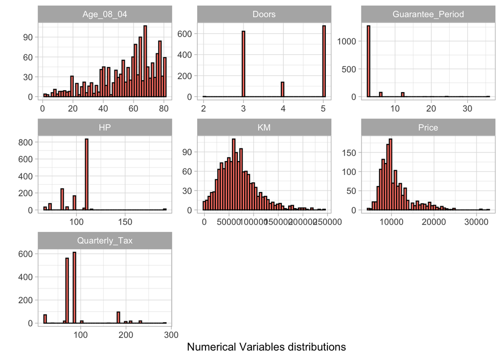

```r
ToyotaCorollaNum = ToyotaCorolla[, c(1,2,3,5,7,8,10)]
# gather transforms data into two columns with "key" and "value"
ToyotaCorollaNum %>% gather() %>%
  ggplot(aes(value)) +                                           # plotting the value
  facet_wrap(~ key, scales = "free") +                           # making one plot for each key with facet
  geom_histogram(color = "black", fill = "#FA8072", bins = 50) + # making histograms
  theme_light() +                                                # aesthetic theme for our plots
  labs(x = "Numerical Variables distributions", y = "")          # label of the figure
```

```r
rm(ToyotaCorollaNum) # removing this object as it won't be used anymore
```

We see that `KM` and `Price` seem to have similar distributions. Together with `Age_08_04`, the three of them have the most “spread out” distributions, whereas all other variables are concentrated around a smaller set of values. This corresponds with our unique values table.

Now, we plot the distributions of our dummy variables.

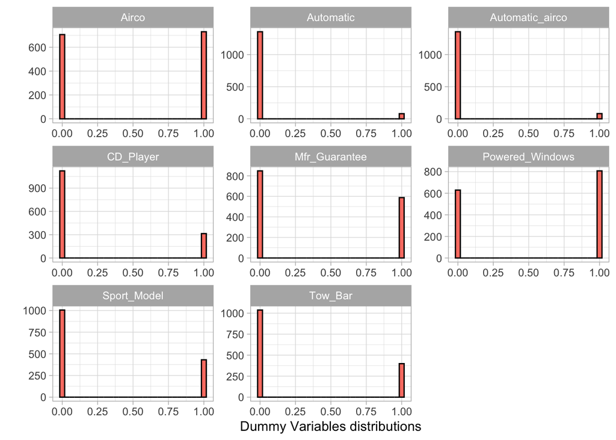

```r
ToyotaCorollaCat = ToyotaCorolla[, c(6,9,11,12,13,14,15,16)]
# gather transforms data into two columns with "key" and "value"
ToyotaCorollaCat %>% gather() %>%
  ggplot(aes(value)) +                                 # plotting the value
  facet_wrap(~ key, scales = "free") +                 # making one plot for each key with facet
  geom_histogram(color = "black", fill = "#FA8072") +  # making histograms
  theme_light() +                                      # aesthetic theme for our plots
  labs(x = "Dummy Variables distributions", y = "")    # label of the figure
```

```r
rm(ToyotaCorollaCat) # removing this object as it won't be used anymore
```

We see that some variables tend to be more evenly distributed ( `Airco`, `Mfr_Guarantee` and `Powered_Windows`) whereas in other variables, the presence of the characteristic is much rarer (`Automatic` and `Automatic_airco` are the most extreme examples).

Lastly, we plot the distribution of our categorical variable, `Fuel_Type`.

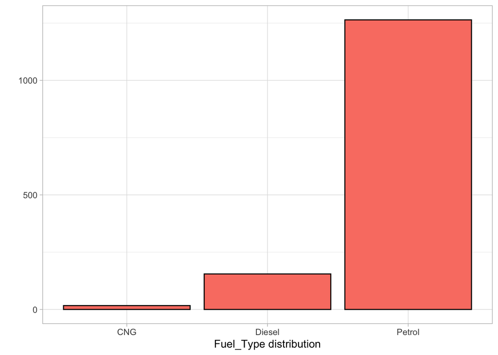

```r
ggplot(ToyotaCorolla, aes(x = Fuel_Type)) +     # plotting Fuel_Type
  geom_bar(color = "black", fill = "#FA8072") + # making a bar chart
  theme_light() +                               # aesthetic theme for our plots
  labs(x = "Fuel_Type distribution", y = "")    # label of the figure
```

Clearly, CNG and Diesel fuels are much rarer than Petrol in this data set.

For a linear regression, `Fuel_Type` needs to be converted to two dummy variables, one for Petrol and one for Diesel. We don’t need a dummy variable for CGR, as it would be a perfect linear combination of the other two dummies. The linear regression `lm()` function takes care of this by itself, so we do not need to manually transform `Fuel_Type` into dummies.

We now split our data into training (50%), validation (30%) and test (20%) sets.

```r
set.seed(111)  # set seed for reproducing the partition

# generating training set index
train.index <- sample(c(1:nrow(ToyotaCorolla)), 0.5*nrow(ToyotaCorolla))
# generating validation set index taken from the complementary of training set
valid.index <- sample(setdiff(c(1:nrow(ToyotaCorolla)), train.index), 0.3*nrow(ToyotaCorolla))
# defining test set index as complementary of (train.index + valid.index)
test.index  <- setdiff(c(1:nrow(ToyotaCorolla)), union(train.index, valid.index))

# creating data tables Train, Valid and Test using the indexes
Train <- ToyotaCorolla[train.index, ]
Valid <- ToyotaCorolla[valid.index, ]
Test <- ToyotaCorolla[test.index, ]

# removing indexes as they aren't used anymore
rm(train.index, valid.index, test.index)
```

```r
# preProcess from the caret package to compute means and sd on Train for scaling
norm.values <- preProcess(ToyotaCorolla[, c(1,2,3,5,7,8,10)], method=c("center", "scale"))
# scaling Train, Valid and Test
Train[, c(1,2,3,5,7,8,10)] <- predict(norm.values, Train[, c(1,2,3,5,7,8,10)])
Valid[, c(1,2,3,5,7,8,10)] <- predict(norm.values, Valid[, c(1,2,3,5,7,8,10)])
 Test[, c(1,2,3,5,7,8,10)] <- predict(norm.values,  Test[, c(1,2,3,5,7,8,10)])
```

We are now ready to perform a linear regression.

```r
# we compute the linear regression with lm, using Price as our dependent variable
# ~ . means that we use every other variable as predictor

Toyota.LM <- lm(Price ~ ., data = Train)
summary(Toyota.LM) # summary displays the results of our regression
```

```
##
## Call:
## lm(formula = Price ~ ., data = Train)
##
## Residuals:
##      Min       1Q   Median       3Q      Max
## -1.31328 -0.20310 -0.01216  0.18313  2.01585
##
## Coefficients:
##                  Estimate Std. Error t value             Pr(>|t|)
## (Intercept)      -0.70021    0.12884  -5.435    0.000000075772179 ***
## Age_08_04        -0.54503    0.02068 -26.360 < 0.0000000000000002 ***
## KM               -0.20930    0.01754 -11.930 < 0.0000000000000002 ***
## Fuel_TypeDiesel   0.63150    0.12605   5.010    0.000000690027010 ***
## Fuel_TypePetrol   0.51959    0.13423   3.871             0.000119 ***
## HP                0.13352    0.01727   7.731    0.000000000000037 ***
## Automatic         0.13072    0.05611   2.330             0.020094 *
## Doors             0.04610    0.01331   3.465             0.000564 ***
## Quarterly_Tax     0.17065    0.02379   7.173    0.000000000001868 ***
## Mfr_Guarantee     0.03222    0.02739   1.176             0.239890
## Guarantee_Period  0.06208    0.01286   4.828    0.000001696482960 ***
## Airco             0.04692    0.03295   1.424             0.154935
## Automatic_airco   0.89466    0.06423  13.928 < 0.0000000000000002 ***
## CD_Player         0.09759    0.03776   2.585             0.009943 **
## Powered_Windows   0.12934    0.03182   4.065    0.000053411831465 ***
## Sport_Model       0.07524    0.03031   2.482             0.013287 *
## Tow_Bar          -0.07316    0.02977  -2.458             0.014226 *
## ---
## Signif. codes:  0 '***' 0.001 '**' 0.01 '*' 0.05 '.' 0.1 ' ' 1
##
## Residual standard error: 0.3395 on 701 degrees of freedom
## Multiple R-squared:  0.8985, Adjusted R-squared:  0.8962
## F-statistic: 387.9 on 16 and 701 DF,  p-value: < 0.00000000000000022
```

We can see that most variables have small $p$-values and the $p$-value of the $F$-statistic (which acts as a kind of collective $p$-value in multilinear regressions) is also extremely small. This indicates that our coefficients have a significant impact on our dependent variable (`Price`). `Airco` and `Mfr_Guarantee` have $p$-values bigger than 0.05, so they might not have a significant impact.

The standard error $\hat\sigma$ is 0.34, it isn’t very small but not too big either. The $R^2$ and $R^2_{adj}$ values are quite close to 0.9, which means that roughly 90% of variation in price is explained by our model. This is a good value.

# 1 What appear to be the three or four most important car specifications for predicting the car’s price?

The variables whose $\hat\beta$ coefficients have the greatest impact are:

- `Automatic_airco` (0.89)
- `Age_08_04` (-0.55)
- `Fuel_TypeDiesel` (0.63) and `Fuel_TypePetrol` (0.52)

`Automatic_airco` and the two `Fuel_Type` dummies have a positive impact on price, whereas age `Age_08_04` has a negative impact. This seems logical, as older cars tend to be sold for lower prices.

We can note that `KM` and `Tow_Bar` have a negative influence of the retail price (however, $\hat\beta_{TowBar}$ is quite small, so the influence isn’t very impactful).

# 2 Using metrics you consider useful, assess the performance of the model in predicting prices.

First, we will construct a data table which contains the `Price` column from our validation set and the predicted prices of the validation set which we get through our linear model `Toyota.LM`.

```r
norm.values$mean[1] # mean of price
```

```
##    Price
## 10730.82
```

```r
norm.values$std[1]  # standard deviation of price
```

```
##    Price
## 3626.965
```

When we standardized, we had
$$Price_{norm} = \dfrac{Price -
\mu}{\sigma}$$
Thus, we will compute now
$$Price = \sigma \cdot Price_{norm} +
\mu$$

We also add a column which computes the residuals by subtracting the first two columns together once they are denormalized.

```r
# creating the data table by taking the Price column from Valid and
# using the predict() function to predict prices of Valid with Toyota.LM
ValidAccuracy <- data.table("Values" = Valid$Price, "PredictedValues" = predict(Toyota.LM, Valid))
# scaling back the two columns to their original scales
ValidAccuracy <- ValidAccuracy[, Values := Values*norm.values$std[1] + norm.values$mean[1] ]
ValidAccuracy <- ValidAccuracy[, PredictedValues :=
                                 PredictedValues*norm.values$std[1] + norm.values$mean[1] ]
# adding Residuals column by subtracting Values - PredictedValues
ValidAccuracy <- ValidAccuracy[, Residuals := Values - PredictedValues]
# displaying the first rows of ValidAccuracy
head(ValidAccuracy)
```

```
##    Values PredictedValues   Residuals
## 1:   9950       13729.426 -3779.42636
## 2:  13950       14483.843  -533.84282
## 3:   6500        6715.897  -215.89703
## 4:   8500        8806.870  -306.86996
## 5:   7750        7837.836   -87.83591
## 6:   8750        7164.669  1585.33057
```

To get an idea of our Residuals, we will plot the following:

- Boxplot of Residuals
- Histogram of Residuals
- Residuals versus Predicted Values Scatterplot
- Normal QQ Plot of Residuals

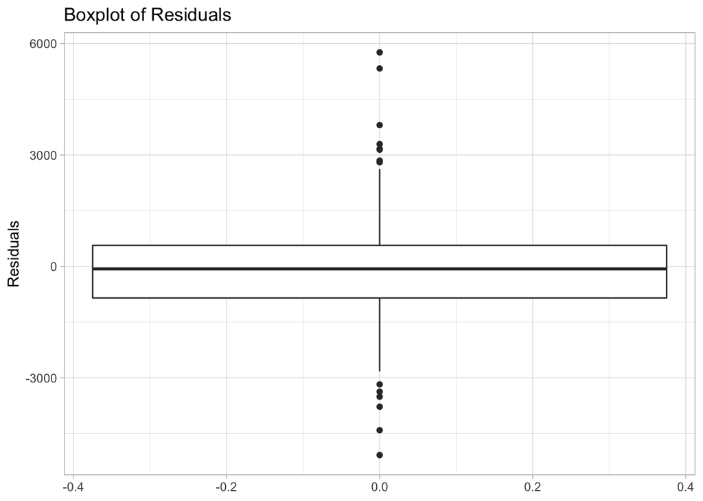

```r
ggplot(data = ValidAccuracy, aes(y = Residuals)) +       # plotting residuals
  geom_boxplot() +                                       # making boxplot
  theme_light() +                                        # changing aesthetic theme
  labs(y = "Residuals", title = "Boxplot of Residuals")  # writing labels
```

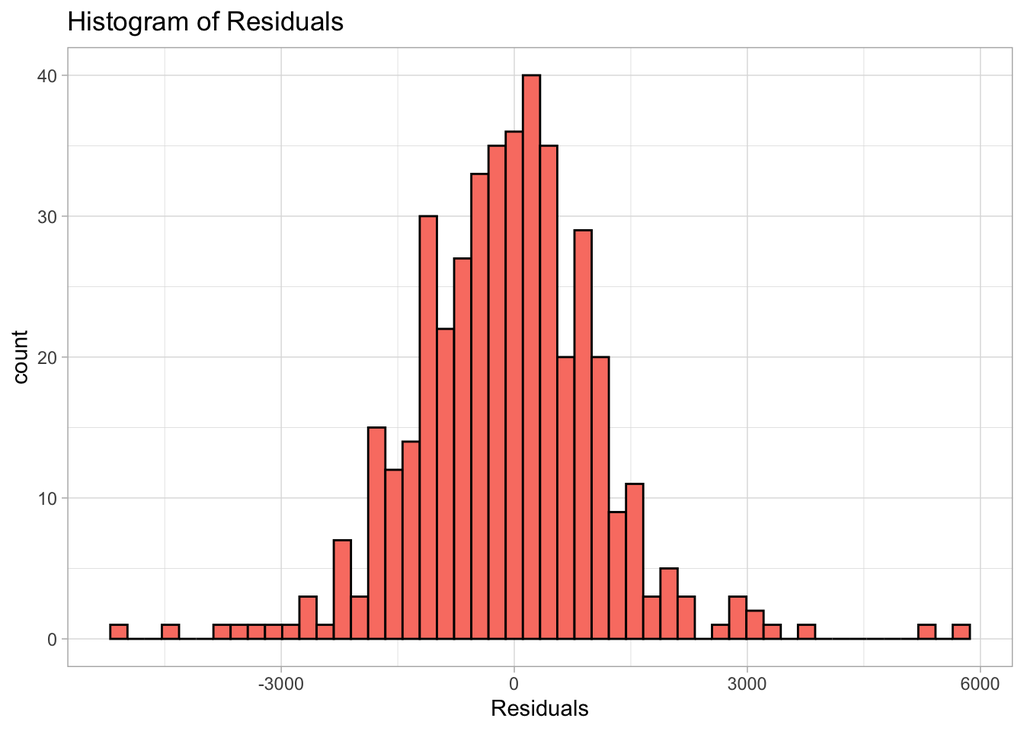

```r
# same as previous plot but using geom_histogram to draw the histogram
ggplot(data = ValidAccuracy, aes(Residuals)) +
  geom_histogram(color = "black", fill = "#FA8072", bins = 50) +
  theme_light() +
  labs(title = "Histogram of Residuals")
```

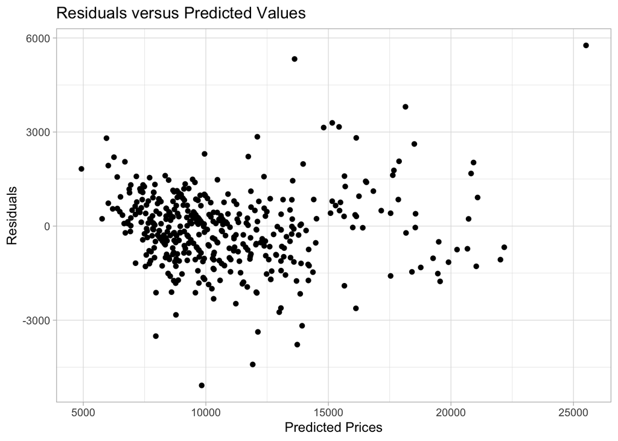

```r
# same as previous plot but using geom_point to draw points on the plot
ggplot(data = ValidAccuracy, aes(x = PredictedValues, y = Residuals)) +
  geom_point() +
  theme_light() +
  labs(x = "Predicted Prices", y = "Residuals", title = "Residuals versus Predicted Values")
```

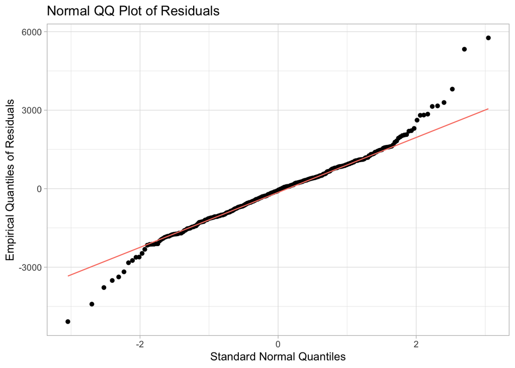

```r
# same as previous plot but using geom_qq to draw residuals points on the plot and
# geom_qq_line to draw the straight line
ggplot(data = ValidAccuracy, aes(sample = Residuals)) +
  geom_qq() +
  geom_qq_line(color = "#FA8072") +
  theme_light() +
  labs(x = "Standard Normal Quantiles", y = "Empirical Quantiles of Residuals",
       title = "Normal QQ Plot of Residuals")
```

The boxplot shows that almost all residuals are inside $[-3000,3000]$ and the median is close to 0, as we would expect.

The histogram shows that the residuals are bell-shaped, but the extreme values seem to be spreading further away than for a normal distribution. We can clearly see that the main portion of residuals is between $[-1500,1500]$. This means that the price estimation will vary by $\pm 1500 €$ in the majority of cases.

The Residuals versus Predicted Values plot shows that again residuals concentrate around zero. Furthermore, we can see that extreme positive residuals correspond to higher values of predicted prices, whereas extreme negative residuals correspond to lower predicted prices. Let us recall that residuals are defined as `Values - PredictedValues`, meaning that a positive residual is an underestimation of price while a negative residual is an overestimation of price. Then, we can deduce that the extreme positive residuals are cars with higher prices which are underestimated and extreme negative residuals are cars with lower prices which are overestimated.

The QQ plot of residuals shows that the residuals are straying away from a normal distribution when we get towards extreme values. However, the book states that the model can be very good for prediction even if residuals aren’t normally distributed. We are more concerned with normality when we are trying to fit a regression model.

Now, we will use the `accuracy` function from the `forecast` package. This function computes **ME**, **RMSE**, **MAE**, **MPE** and **MAPE**.

Let us recall what these prediction measures are. We cite the book (chapter 5.2, page 119). We denote the residuals by $r = y - \hat y$.

1. **ME** (Mean Error) gives an indication of whether the predictions are on average over- or under-predicting the outcome variable.
   $$ME = \dfrac{1}{n}
   \sum_{i=1}^{n}r_i$$
2. **RMSE** (Root Mean Squared Error) is similar to the standard error of estimate in linear regression, except that it is computed on the validation data rather than on the training data.
   $$RMSE
   = \sqrt{\dfrac{1}{n}\sum_{i=1}^{n}r_i^2}$$
3. **MAE** (Mean Absolute Error) gives the magnitude of the average absolute error.
   $$MAE =
   \dfrac{1}{n} \sum_{i=1}^{n}|r_i|$$
4. **MPE** (Mean Percentage Error) gives the percentage score of how predictions deviate from the actual values (on average), taking into account the direction of the error.
   $$MPE = 100 \cdot \dfrac{1}{n} \sum_{i=1}^{n}
   \dfrac{r_i}{y_i}$$
5. **MAPE** (Mean Absolute Percentage Error) gives a percentage score of how predictions deviate (on average) from the actual values.
   $$MAPE = 100 \cdot \dfrac{1}{n}
   \sum_{i=1}^{n} \left| \dfrac{r_i}{y_i}\right|$$

```r
# computing accuracy measures for valid
accuracy(ValidAccuracy$PredictedValues, ValidAccuracy$Values)
```

```
##                 ME     RMSE      MAE       MPE     MAPE
## Test set -95.91656 1214.533 900.5001 -2.108908 9.049204
```

We can deduce that

1. On average, the model over-predicts price by $96€$ (recall that negative residuals mean we are overestimating).
2. Predictions will vary from true values by $\pm 1215 €$ most of the time.
3. The magnitude of errors is of $901€$ on average.
4. Predictions will vary from true values by $-2.11\%$ on average (direction of errors is taken into account).
5. The magnitude of errors will vary by $9.05\%$ on average.

We create a `TestAccuracy` table like we did for `ValidAccuracy`.

```r
# creating the data table by taking the Price column from Test and
# using the predict() function to predict prices of Test with Toyota.LM
TestAccuracy <- data.table("Values" = Test$Price, "PredictedValues" = predict(Toyota.LM, Test))
# scaling back the two columns to their original scales
TestAccuracy <- TestAccuracy[, Values := Values*norm.values$std[1] + norm.values$mean[1] ]
TestAccuracy <- TestAccuracy[, PredictedValues :=
                                 PredictedValues*norm.values$std[1] + norm.values$mean[1] ]
# adding Residuals column by subtracting Values - PredictedValues
TestAccuracy <- TestAccuracy[, Residuals := Values - PredictedValues]
# displaying the first rows of TestAccuracy
head(TestAccuracy)
```

```
##    Values PredictedValues  Residuals
## 1:  13950        15771.65 -1821.6544
## 2:  12950        15053.44 -2103.4421
## 3:  16900        15177.44  1722.5643
## 4:  22750        20647.33  2102.6739
## 5:  17495        18195.50  -700.4964
## 6:  15750        18116.78 -2366.7777
```

We compute the same four plots:

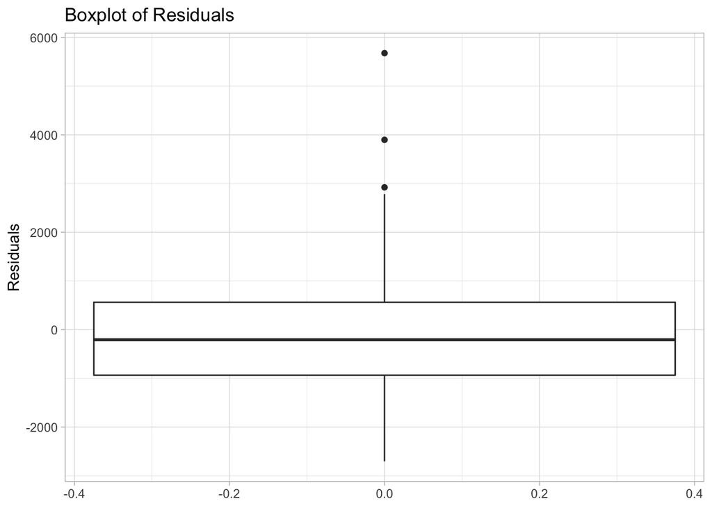

```r
ggplot(data = TestAccuracy, aes(y = Residuals)) +        # plotting residuals
  geom_boxplot() +                                       # making boxplot
  theme_light() +                                        # changing aesthetic theme
  labs(y = "Residuals", title = "Boxplot of Residuals")  # writing labels
```

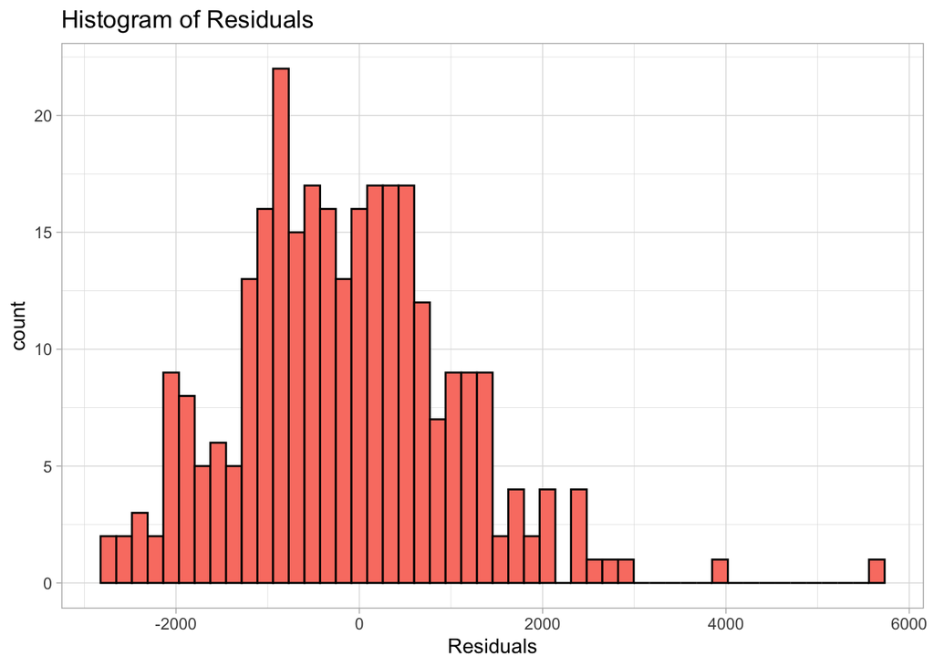

```r
# same as previous plot but using geom_histogram to draw the histogram
ggplot(data = TestAccuracy, aes(Residuals)) +
  geom_histogram(color = "black", fill = "#FA8072", bins = 50) +
  theme_light() +
  labs(title = "Histogram of Residuals")
```

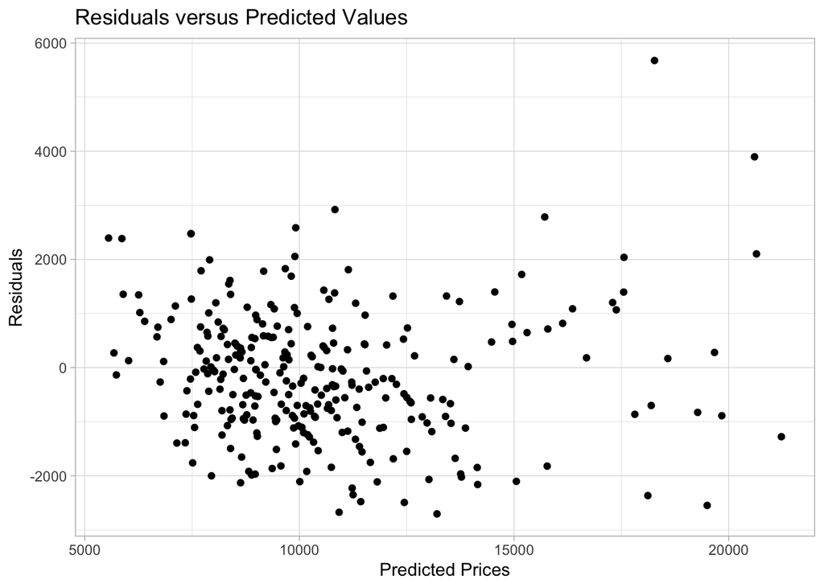

```r
# same as previous plot but using geom_point to draw points on the plot
ggplot(data = TestAccuracy, aes(x = PredictedValues, y = Residuals)) +
  geom_point() +
  theme_light() +
  labs(x = "Predicted Prices", y = "Residuals", title = "Residuals versus Predicted Values")
```

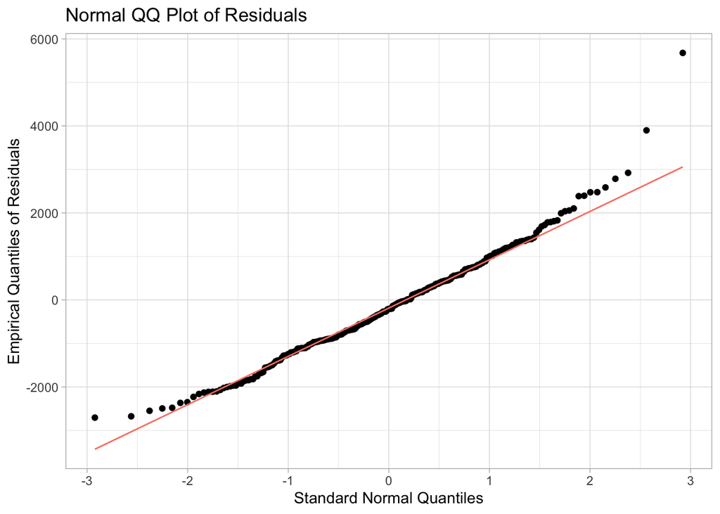

```r
# same as previous plot but using geom_qq to draw residuals points on the plot and
# geom_qq_line to draw the straight line
ggplot(data = TestAccuracy, aes(sample = Residuals)) +
  geom_qq() +
  geom_qq_line(color = "#FA8072") +
  theme_light() +
  labs(x = "Standard Normal Quantiles", y = "Empirical Quantiles of Residuals",
       title = "Normal QQ Plot of Residuals")
```

We can see that our test data is quite similar to our validation data, but negative residuals are less extreme than before. The difference is crystal clear when looking at summaries of `Residuals` in both tables.

```r
# computing summary of valid and test residuals
summary(ValidAccuracy$Residuals)
```

```
##     Min.  1st Qu.   Median     Mean  3rd Qu.     Max.
## -5080.81  -850.39   -67.28   -95.92   566.09  5762.78
```

```r
summary(TestAccuracy$Residuals)
```

```
##    Min. 1st Qu.  Median    Mean 3rd Qu.    Max.
## -2705.2  -935.4  -207.7  -152.9   562.5  5678.1
```

Residuals in our test set have a minimal value that is twice as small as the minimum of our validation set! Let us see if this difference will impact the accuracy measures.

```r
# computing accuracy measures for valid and test in order to compare
accuracy(ValidAccuracy$PredictedValues, ValidAccuracy$Values)
```

```
##                 ME     RMSE      MAE       MPE     MAPE
## Test set -95.91656 1214.533 900.5001 -2.108908 9.049204
```

```r
accuracy(TestAccuracy$PredictedValues, TestAccuracy$Values)
```

```
##                 ME     RMSE      MAE       MPE     MAPE
## Test set -152.8982 1203.863 946.8009 -2.565436 9.505479
```

ME is smaller than with the validation set, suggesting a bigger tendency to overestimate price on average ($-153€$ instead of $-96€$). However, the four other measures stayed close to their old values.

In conclusion, this linear regression model gives good but not extraordinary results.

If it is satisfactory or “good enough” will depend on the requirements and goals of the car dealership, the main issue being if the variance in predictions is too large or not (RMSE being a little more than $1200€$, we would need to assess with management if this value is acceptable or not).

The tendency of the model to slightly overestimate prices is also a flaw. In my opinion, it would be better to have a slight underestimation of prices (and thus profit) than the contrary, as overestimating means the projections are a bit too “enthusiastic”. However, the overestimation seems to be under $200€$, which compared to the overall price of a car isn’t too impactful.